# HR_Analytics

### HR Analytics - Employees Engagement

In this EDA project we would be performing HR Analytics - Employees Engagement Analysis which is present in kaggle platform. In this EDA project we will analyse and visualize our dataset.

The job role of a HR is not that easy as it seems from the outside

The HR's have to actively participate in recruitment process, helping employees with their issues, maintaining positive environment, analysing the performance and efficiency, and many more.

Amonge all the job responsiblities of an HR, evaluating the performance and efficiency of the employees is considered the most difficult task.

The difficulty level of the task is directly proportional to number of employees who work under that particular HR.

Thus, to deal with it we have to come up with Exploratory Data Analysis (EDA) project.

Here we will be performing different analysis and visualizations using the Employees Engagement Dataset to obtain some valuable insights.

```python
import pandas as pd
import numpy as np
import matplotlib.pyplot as plt
import seaborn as sns

import warnings
warnings.filterwarnings('ignore')
```

```python
df = pd.read_csv('HR.csv')
df
```

|  | Employee_Name | EmpID | MarriedID | MaritalStatusID | GenderID | EmpStatusID | DeptID | PerfScoreID | FromDiversityJobFairID | Salary | ... | ManagerName | ManagerID | RecruitmentSource | PerformanceScore | EngagementSurvey | EmpSatisfaction | SpecialProjectsCount | LastPerformanceReview_Date | DaysLateLast30 | Absences |
| --- | --- | --- | --- | --- | --- | --- | --- | --- | --- | --- | --- | --- | --- | --- | --- | --- | --- | --- | --- | --- | --- |
| 0 | Adinolfi, Wilson K | 10026 | 0 | 0 | 1 | 1 | 5 | 4 | 0 | 62506 | ... | Michael Albert | 22.0 | LinkedIn | Exceeds | 4.60 | 5 | 0 | 1/17/2019 | 0 | 1 |
| 1 | Ait Sidi, Karthikeyan | 10084 | 1 | 1 | 1 | 5 | 3 | 3 | 0 | 104437 | ... | Simon Roup | 4.0 | Indeed | Fully Meets | 4.96 | 3 | 6 | 2/24/2016 | 0 | 17 |
| 2 | Akinkuolie, Sarah | 10196 | 1 | 1 | 0 | 5 | 5 | 3 | 0 | 64955 | ... | Kissy Sullivan | 20.0 | LinkedIn | Fully Meets | 3.02 | 3 | 0 | 5/15/2012 | 0 | 3 |
| 3 | Alagbe,Trina | 10088 | 1 | 1 | 0 | 1 | 5 | 3 | 0 | 64991 | ... | Elijiah Gray | 16.0 | Indeed | Fully Meets | 4.84 | 5 | 0 | 1/3/2019 | 0 | 15 |
| 4 | Anderson, Carol | 10069 | 0 | 2 | 0 | 5 | 5 | 3 | 0 | 50825 | ... | Webster Butler | 39.0 | Google Search | Fully Meets | 5.00 | 4 | 0 | 2/1/2016 | 0 | 2 |
| ... | ... | ... | ... | ... | ... | ... | ... | ... | ... | ... | ... | ... | ... | ... | ... | ... | ... | ... | ... | ... | ... |
| 306 | Woodson, Jason | 10135 | 0 | 0 | 1 | 1 | 5 | 3 | 0 | 65893 | ... | Kissy Sullivan | 20.0 | LinkedIn | Fully Meets | 4.07 | 4 | 0 | 2/28/2019 | 0 | 13 |
| 307 | Ybarra, Catherine | 10301 | 0 | 0 | 0 | 5 | 5 | 1 | 0 | 48513 | ... | Brannon Miller | 12.0 | Google Search | PIP | 3.20 | 2 | 0 | 9/2/2015 | 5 | 4 |
| 308 | Zamora, Jennifer | 10010 | 0 | 0 | 0 | 1 | 3 | 4 | 0 | 220450 | ... | Janet King | 2.0 | Employee Referral | Exceeds | 4.60 | 5 | 6 | 2/21/2019 | 0 | 16 |
| 309 | Zhou, Julia | 10043 | 0 | 0 | 0 | 1 | 3 | 3 | 0 | 89292 | ... | Simon Roup | 4.0 | Employee Referral | Fully Meets | 5.00 | 3 | 5 | 2/1/2019 | 0 | 11 |
| 310 | Zima, Colleen | 10271 | 0 | 4 | 0 | 1 | 5 | 3 | 0 | 45046 | ... | David Stanley | 14.0 | LinkedIn | Fully Meets | 4.50 | 5 | 0 | 1/30/2019 | 0 | 2 |

311 rows × 36 columns

```python
df.columns
```

```
Index(['Employee_Name', 'EmpID', 'MarriedID', 'MaritalStatusID', 'GenderID',
       'EmpStatusID', 'DeptID', 'PerfScoreID', 'FromDiversityJobFairID',
       'Salary', 'Termd', 'PositionID', 'Position', 'State', 'Zip', 'DOB',
       'Sex', 'MaritalDesc', 'CitizenDesc', 'HispanicLatino', 'RaceDesc',
       'DateofHire', 'DateofTermination', 'TermReason', 'EmploymentStatus',
       'Department', 'ManagerName', 'ManagerID', 'RecruitmentSource',
       'PerformanceScore', 'EngagementSurvey', 'EmpSatisfaction',
       'SpecialProjectsCount', 'LastPerformanceReview_Date', 'DaysLateLast30',
       'Absences'],
      dtype='object')
```

```python
df.shape
```

```
(311, 36)
```

```python
df.dtypes
```

```
Employee_Name                  object
EmpID                           int64
MarriedID                       int64
MaritalStatusID                 int64
GenderID                        int64
EmpStatusID                     int64
DeptID                          int64
PerfScoreID                     int64
FromDiversityJobFairID          int64
Salary                          int64
Termd                           int64
PositionID                      int64
Position                       object
State                          object
Zip                             int64
DOB                            object
Sex                            object
MaritalDesc                    object
CitizenDesc                    object
HispanicLatino                 object
RaceDesc                       object
DateofHire                     object
DateofTermination              object
TermReason                     object
EmploymentStatus               object
Department                     object
ManagerName                    object
ManagerID                     float64
RecruitmentSource              object
PerformanceScore               object
EngagementSurvey              float64
EmpSatisfaction                 int64
SpecialProjectsCount            int64
LastPerformanceReview_Date     object
DaysLateLast30                  int64
Absences                        int64
dtype: object
```

```python
df.info()
```

```
<class 'pandas.core.frame.DataFrame'>
RangeIndex: 311 entries, 0 to 310
Data columns (total 36 columns):
 #   Column                      Non-Null Count  Dtype
---  ------                      --------------  -----
 0   Employee_Name               311 non-null    object
 1   EmpID                       311 non-null    int64
 2   MarriedID                   311 non-null    int64
 3   MaritalStatusID             311 non-null    int64
 4   GenderID                    311 non-null    int64
 5   EmpStatusID                 311 non-null    int64
 6   DeptID                      311 non-null    int64
 7   PerfScoreID                 311 non-null    int64
 8   FromDiversityJobFairID      311 non-null    int64
 9   Salary                      311 non-null    int64
```

[output cut: 28 more lines]

```python
df.describe()
```

|  | EmpID | MarriedID | MaritalStatusID | GenderID | EmpStatusID | DeptID | PerfScoreID | FromDiversityJobFairID | Salary | Termd | PositionID | Zip | ManagerID | EngagementSurvey | EmpSatisfaction | SpecialProjectsCount | DaysLateLast30 | Absences |
| --- | --- | --- | --- | --- | --- | --- | --- | --- | --- | --- | --- | --- | --- | --- | --- | --- | --- | --- |
| count | 311.000000 | 311.000000 | 311.000000 | 311.000000 | 311.000000 | 311.000000 | 311.000000 | 311.000000 | 311.000000 | 311.000000 | 311.000000 | 311.000000 | 303.000000 | 311.000000 | 311.000000 | 311.000000 | 311.000000 | 311.000000 |
| mean | 10156.000000 | 0.398714 | 0.810289 | 0.434084 | 2.392283 | 4.610932 | 2.977492 | 0.093248 | 69020.684887 | 0.334405 | 16.845659 | 6555.482315 | 14.570957 | 4.110000 | 3.890675 | 1.218650 | 0.414791 | 10.237942 |
| std | 89.922189 | 0.490423 | 0.943239 | 0.496435 | 1.794383 | 1.083487 | 0.587072 | 0.291248 | 25156.636930 | 0.472542 | 6.223419 | 16908.396884 | 8.078306 | 0.789938 | 0.909241 | 2.349421 | 1.294519 | 5.852596 |
| min | 10001.000000 | 0.000000 | 0.000000 | 0.000000 | 1.000000 | 1.000000 | 1.000000 | 0.000000 | 45046.000000 | 0.000000 | 1.000000 | 1013.000000 | 1.000000 | 1.120000 | 1.000000 | 0.000000 | 0.000000 | 1.000000 |
| 25% | 10078.500000 | 0.000000 | 0.000000 | 0.000000 | 1.000000 | 5.000000 | 3.000000 | 0.000000 | 55501.500000 | 0.000000 | 18.000000 | 1901.500000 | 10.000000 | 3.690000 | 3.000000 | 0.000000 | 0.000000 | 5.000000 |
| 50% | 10156.000000 | 0.000000 | 1.000000 | 0.000000 | 1.000000 | 5.000000 | 3.000000 | 0.000000 | 62810.000000 | 0.000000 | 19.000000 | 2132.000000 | 15.000000 | 4.280000 | 4.000000 | 0.000000 | 0.000000 | 10.000000 |
| 75% | 10233.500000 | 1.000000 | 1.000000 | 1.000000 | 5.000000 | 5.000000 | 3.000000 | 0.000000 | 72036.000000 | 1.000000 | 20.000000 | 2355.000000 | 19.000000 | 4.700000 | 5.000000 | 0.000000 | 0.000000 | 15.000000 |
| max | 10311.000000 | 1.000000 | 4.000000 | 1.000000 | 5.000000 | 6.000000 | 4.000000 | 1.000000 | 250000.000000 | 1.000000 | 30.000000 | 98052.000000 | 39.000000 | 5.000000 | 5.000000 | 8.000000 | 6.000000 | 20.000000 |

# Cleaning of data

```python
df.isnull().sum()
```

```
Employee_Name                   0
EmpID                           0
MarriedID                       0
MaritalStatusID                 0
GenderID                        0
EmpStatusID                     0
DeptID                          0
PerfScoreID                     0
FromDiversityJobFairID          0
Salary                          0
Termd                           0
PositionID                      0
Position                        0
State                           0
Zip                             0
DOB                             0
Sex                             0
MaritalDesc                     0
CitizenDesc                     0
HispanicLatino                  0
RaceDesc                        0
DateofHire                      0
DateofTermination             207
TermReason                      0
EmploymentStatus                0
Department                      0
ManagerName                     0
ManagerID                       8
RecruitmentSource               0
PerformanceScore                0
EngagementSurvey                0
EmpSatisfaction                 0
SpecialProjectsCount            0
LastPerformanceReview_Date      0
DaysLateLast30                  0
Absences                        0
dtype: int64
```

```python
df['DateofTermination']
```

```
0            NaN
1      6/16/2016
2      9/24/2012
3            NaN
4       9/6/2016
         ...
306          NaN
307    9/29/2015
308          NaN
309          NaN
310          NaN
Name: DateofTermination, Length: 311, dtype: object
```

```python
df.fillna('0', inplace = True)
df['DateofTermination']
```

```
0              0
1      6/16/2016
2      9/24/2012
3              0
4       9/6/2016
         ...
306            0
307    9/29/2015
308            0
309            0
310            0
Name: DateofTermination, Length: 311, dtype: object
```

```python
df.isnull().sum()
```

```
Employee_Name                 0
EmpID                         0
MarriedID                     0
MaritalStatusID               0
GenderID                      0
EmpStatusID                   0
DeptID                        0
PerfScoreID                   0
FromDiversityJobFairID        0
Salary                        0
Termd                         0
PositionID                    0
Position                      0
State                         0
Zip                           0
DOB                           0
Sex                           0
MaritalDesc                   0
CitizenDesc                   0
HispanicLatino                0
RaceDesc                      0
DateofHire                    0
DateofTermination             0
TermReason                    0
EmploymentStatus              0
Department                    0
ManagerName                   0
ManagerID                     0
RecruitmentSource             0
PerformanceScore              0
EngagementSurvey              0
EmpSatisfaction               0
SpecialProjectsCount          0
LastPerformanceReview_Date    0
DaysLateLast30                0
Absences                      0
dtype: int64
```

```python
df.duplicated().sum()
```

```
0
```

```python
df.head()
```

|  | Employee_Name | EmpID | MarriedID | MaritalStatusID | GenderID | EmpStatusID | DeptID | PerfScoreID | FromDiversityJobFairID | Salary | ... | ManagerName | ManagerID | RecruitmentSource | PerformanceScore | EngagementSurvey | EmpSatisfaction | SpecialProjectsCount | LastPerformanceReview_Date | DaysLateLast30 | Absences |
| --- | --- | --- | --- | --- | --- | --- | --- | --- | --- | --- | --- | --- | --- | --- | --- | --- | --- | --- | --- | --- | --- |
| 0 | Adinolfi, Wilson K | 10026 | 0 | 0 | 1 | 1 | 5 | 4 | 0 | 62506 | ... | Michael Albert | 22.0 | LinkedIn | Exceeds | 4.60 | 5 | 0 | 1/17/2019 | 0 | 1 |
| 1 | Ait Sidi, Karthikeyan | 10084 | 1 | 1 | 1 | 5 | 3 | 3 | 0 | 104437 | ... | Simon Roup | 4.0 | Indeed | Fully Meets | 4.96 | 3 | 6 | 2/24/2016 | 0 | 17 |
| 2 | Akinkuolie, Sarah | 10196 | 1 | 1 | 0 | 5 | 5 | 3 | 0 | 64955 | ... | Kissy Sullivan | 20.0 | LinkedIn | Fully Meets | 3.02 | 3 | 0 | 5/15/2012 | 0 | 3 |
| 3 | Alagbe,Trina | 10088 | 1 | 1 | 0 | 1 | 5 | 3 | 0 | 64991 | ... | Elijiah Gray | 16.0 | Indeed | Fully Meets | 4.84 | 5 | 0 | 1/3/2019 | 0 | 15 |
| 4 | Anderson, Carol | 10069 | 0 | 2 | 0 | 5 | 5 | 3 | 0 | 50825 | ... | Webster Butler | 39.0 | Google Search | Fully Meets | 5.00 | 4 | 0 | 2/1/2016 | 0 | 2 |

5 rows × 36 columns

```python
df.tail()
```

|  | Employee_Name | EmpID | MarriedID | MaritalStatusID | GenderID | EmpStatusID | DeptID | PerfScoreID | FromDiversityJobFairID | Salary | ... | ManagerName | ManagerID | RecruitmentSource | PerformanceScore | EngagementSurvey | EmpSatisfaction | SpecialProjectsCount | LastPerformanceReview_Date | DaysLateLast30 | Absences |
| --- | --- | --- | --- | --- | --- | --- | --- | --- | --- | --- | --- | --- | --- | --- | --- | --- | --- | --- | --- | --- | --- |
| 306 | Woodson, Jason | 10135 | 0 | 0 | 1 | 1 | 5 | 3 | 0 | 65893 | ... | Kissy Sullivan | 20.0 | LinkedIn | Fully Meets | 4.07 | 4 | 0 | 2/28/2019 | 0 | 13 |
| 307 | Ybarra, Catherine | 10301 | 0 | 0 | 0 | 5 | 5 | 1 | 0 | 48513 | ... | Brannon Miller | 12.0 | Google Search | PIP | 3.20 | 2 | 0 | 9/2/2015 | 5 | 4 |
| 308 | Zamora, Jennifer | 10010 | 0 | 0 | 0 | 1 | 3 | 4 | 0 | 220450 | ... | Janet King | 2.0 | Employee Referral | Exceeds | 4.60 | 5 | 6 | 2/21/2019 | 0 | 16 |
| 309 | Zhou, Julia | 10043 | 0 | 0 | 0 | 1 | 3 | 3 | 0 | 89292 | ... | Simon Roup | 4.0 | Employee Referral | Fully Meets | 5.00 | 3 | 5 | 2/1/2019 | 0 | 11 |
| 310 | Zima, Colleen | 10271 | 0 | 4 | 0 | 1 | 5 | 3 | 0 | 45046 | ... | David Stanley | 14.0 | LinkedIn | Fully Meets | 4.50 | 5 | 0 | 1/30/2019 | 0 | 2 |

5 rows × 36 columns

```python
df.sample(5)
```

|  | Employee_Name | EmpID | MarriedID | MaritalStatusID | GenderID | EmpStatusID | DeptID | PerfScoreID | FromDiversityJobFairID | Salary | ... | ManagerName | ManagerID | RecruitmentSource | PerformanceScore | EngagementSurvey | EmpSatisfaction | SpecialProjectsCount | LastPerformanceReview_Date | DaysLateLast30 | Absences |
| --- | --- | --- | --- | --- | --- | --- | --- | --- | --- | --- | --- | --- | --- | --- | --- | --- | --- | --- | --- | --- | --- |
| 305 | Wolk, Hang T | 10174 | 0 | 0 | 0 | 1 | 5 | 3 | 0 | 60446 | ... | David Stanley | 14.0 | LinkedIn | Fully Meets | 3.40 | 4 | 0 | 2/21/2019 | 0 | 14 |
| 223 | Potts, Xana | 10124 | 1 | 1 | 0 | 1 | 6 | 3 | 0 | 61844 | ... | Lynn Daneault | 21.0 | Website | Fully Meets | 4.20 | 5 | 0 | 2/1/2019 | 0 | 9 |
| 226 | Purinton, Janine | 10262 | 0 | 2 | 0 | 5 | 5 | 3 | 0 | 46430 | ... | Kissy Sullivan | 20.0 | Indeed | Fully Meets | 4.50 | 5 | 0 | 4/2/2013 | 0 | 16 |
| 208 | Osturnka, Adeel | 10021 | 1 | 1 | 1 | 1 | 5 | 4 | 0 | 47414 | ... | Kelley Spirea | 18.0 | LinkedIn | Exceeds | 5.00 | 3 | 0 | 2/7/2019 | 0 | 13 |
| 94 | Foreman, Tanya | 10163 | 1 | 1 | 0 | 5 | 5 | 3 | 0 | 55965 | ... | Ketsia Liebig | 19.0 | Google Search | Fully Meets | 3.66 | 3 | 0 | 1/7/2012 | 0 | 6 |

5 rows × 36 columns

```python
df[df.duplicated() == True]
```

|  | Employee_Name | EmpID | MarriedID | MaritalStatusID | GenderID | EmpStatusID | DeptID | PerfScoreID | FromDiversityJobFairID | Salary | ... | ManagerName | ManagerID | RecruitmentSource | PerformanceScore | EngagementSurvey | EmpSatisfaction | SpecialProjectsCount | LastPerformanceReview_Date | DaysLateLast30 | Absences |
| --- | --- | --- | --- | --- | --- | --- | --- | --- | --- | --- | --- | --- | --- | --- | --- | --- | --- | --- | --- | --- | --- |

0 rows × 36 columns

# EDA(Exploaratory Data Analysis)

Employees with highest salary >> Top 10

```python
df['Salary'].sort_values(ascending = False)[:10]
```

```
150    250000
308    220450
131    180000
96     178000
55     170500
190    157000
240    150290
244    148999
243    140920
76     138888
Name: Salary, dtype: int64
```

```python
df['Salary'].sort_values(ascending = False).head(10)
```

```
150    250000
308    220450
131    180000
96     178000
55     170500
190    157000
240    150290
244    148999
243    140920
76     138888
Name: Salary, dtype: int64
```

Highest Salary is 250000.

Employees who need special attention(PIP)

```python
df['PerformanceScore'].unique()
```

```
array(['Exceeds', 'Fully Meets', 'Needs Improvement', 'PIP'], dtype=object)
```

```python
df[df['PerformanceScore'] == 'PIP']
```

|  | Employee_Name | EmpID | MarriedID | MaritalStatusID | GenderID | EmpStatusID | DeptID | PerfScoreID | FromDiversityJobFairID | Salary | ... | ManagerName | ManagerID | RecruitmentSource | PerformanceScore | EngagementSurvey | EmpSatisfaction | SpecialProjectsCount | LastPerformanceReview_Date | DaysLateLast30 | Absences |
| --- | --- | --- | --- | --- | --- | --- | --- | --- | --- | --- | --- | --- | --- | --- | --- | --- | --- | --- | --- | --- | --- |
| 67 | Delarge, Alex | 10306 | 0 | 0 | 1 | 1 | 6 | 1 | 0 | 61568 | ... | John Smith | 17.0 | Indeed | PIP | 1.93 | 3 | 0 | 1/30/2019 | 6 | 5 |
| 69 | Desimone, Carl | 10310 | 1 | 1 | 1 | 1 | 5 | 1 | 0 | 53189 | ... | Amy Dunn | 11.0 | Indeed | PIP | 1.12 | 2 | 0 | 1/31/2019 | 4 | 9 |
| 72 | Dietrich, Jenna | 10304 | 0 | 0 | 0 | 1 | 6 | 1 | 0 | 59231 | ... | John Smith | 17.0 | Website | PIP | 2.30 | 1 | 0 | 1/29/2019 | 2 | 17 |
| 83 | Erilus, Angela | 10299 | 0 | 3 | 0 | 1 | 5 | 1 | 0 | 56847 | ... | Michael Albert | 22.0 | Indeed | PIP | 3.00 | 1 | 0 | 2/25/2019 | 2 | 5 |
| 90 | Fernandes, Nilson | 10308 | 1 | 1 | 1 | 1 | 5 | 1 | 0 | 64057 | ... | Amy Dunn | 11.0 | Indeed | PIP | 1.56 | 5 | 0 | 1/3/2019 | 6 | 15 |
| 91 | Fett, Boba | 10309 | 0 | 0 | 1 | 1 | 3 | 1 | 0 | 53366 | ... | Peter Monroe | 7.0 | LinkedIn | PIP | 1.20 | 3 | 6 | 2/4/2019 | 3 | 2 |
| 95 | Forrest, Alex | 10305 | 1 | 1 | 1 | 1 | 6 | 3 | 0 | 70187 | ... | Lynn Daneault | 21.0 | Employee Referral | PIP | 2.00 | 5 | 0 | 1/28/2019 | 4 | 7 |
| 112 | Gonzalez, Juan | 10300 | 1 | 1 | 1 | 5 | 5 | 1 | 1 | 68898 | ... | Brannon Miller | 12.0 | Diversity Job Fair | PIP | 3.00 | 3 | 0 | 3/6/2011 | 3 | 10 |
| 188 | Miller, Ned | 10298 | 0 | 0 | 1 | 5 | 5 | 1 | 0 | 55800 | ... | Brannon Miller | 12.0 | LinkedIn | PIP | 3.00 | 2 | 0 | 1/14/2013 | 6 | 6 |
| 205 | O'hare, Lynn | 10303 | 0 | 0 | 0 | 4 | 5 | 1 | 0 | 52674 | ... | Kissy Sullivan | 20.0 | LinkedIn | PIP | 2.33 | 2 | 0 | 3/9/2018 | 6 | 3 |
| 263 | Sparks, Taylor | 10302 | 1 | 1 | 0 | 1 | 5 | 1 | 0 | 64021 | ... | Brannon Miller | 12.0 | Indeed | PIP | 2.40 | 2 | 1 | 2/25/2019 | 6 | 20 |
| 267 | Stansfield, Norman | 10307 | 1 | 1 | 1 | 1 | 6 | 1 | 0 | 58273 | ... | Lynn Daneault | 21.0 | Website | PIP | 1.81 | 2 | 0 | 1/17/2019 | 3 | 5 |
| 307 | Ybarra, Catherine | 10301 | 0 | 0 | 0 | 5 | 5 | 1 | 0 | 48513 | ... | Brannon Miller | 12.0 | Google Search | PIP | 3.20 | 2 | 0 | 9/2/2015 | 5 | 4 |

13 rows × 36 columns

```python
df[df['PerformanceScore'] == 'PIP'].Employee_Name
```

```
67           Delarge, Alex
69         Desimone, Carl
72       Dietrich, Jenna
83          Erilus, Angela
90     Fernandes, Nilson
91              Fett, Boba
95           Forrest, Alex
112         Gonzalez, Juan
188            Miller, Ned
205           O'hare, Lynn
263       Sparks, Taylor
267     Stansfield, Norman
307     Ybarra, Catherine
Name: Employee_Name, dtype: object
```

```python
len(df[df['PerformanceScore'] == 'PIP'].Employee_Name)
```

```
13
```

13 employees need PIP ie. Performance Improvement Plan

```python
df['Absences'].value_counts()
```

```
Absences
4     23
16    23
7     21
2     21
15    20
13    17
14    17
3     16
19    16
6     16
11    15
17    15
1     14
20    14
9     14
5     12
8     11
10    10
12     8
18     8
Name: count, dtype: int64
```

```python
df['Absences'].value_counts(normalize = True)
```

```
Absences
4     0.073955
16    0.073955
7     0.067524
2     0.067524
15    0.064309
13    0.054662
14    0.054662
3     0.051447
19    0.051447
6     0.051447
11    0.048232
17    0.048232
1     0.045016
20    0.045016
9     0.045016
5     0.038585
8     0.035370
10    0.032154
12    0.025723
18    0.025723
Name: proportion, dtype: float64
```

```python
df['Absences'].value_counts(normalize = True) * 100
```

```
Absences
4     7.395498
16    7.395498
7     6.752412
2     6.752412
15    6.430868
13    5.466238
14    5.466238
3     5.144695
19    5.144695
6     5.144695
11    4.823151
17    4.823151
1     4.501608
20    4.501608
9     4.501608
5     3.858521
8     3.536977
10    3.215434
12    2.572347
18    2.572347
Name: proportion, dtype: float64
```

```python
df[df['Absences'] == 20]
```

|  | Employee_Name | EmpID | MarriedID | MaritalStatusID | GenderID | EmpStatusID | DeptID | PerfScoreID | FromDiversityJobFairID | Salary | ... | ManagerName | ManagerID | RecruitmentSource | PerformanceScore | EngagementSurvey | EmpSatisfaction | SpecialProjectsCount | LastPerformanceReview_Date | DaysLateLast30 | Absences |
| --- | --- | --- | --- | --- | --- | --- | --- | --- | --- | --- | --- | --- | --- | --- | --- | --- | --- | --- | --- | --- | --- |
| 15 | Bates, Norman | 10061 | 0 | 0 | 1 | 4 | 5 | 3 | 0 | 57834 | ... | Kelley Spirea | 18.0 | Google Search | Fully Meets | 5.00 | 4 | 0 | 4/5/2017 | 0 | 20 |
| 93 | Fitzpatrick, Michael J | 10093 | 0 | 0 | 1 | 5 | 5 | 3 | 0 | 72609 | ... | Amy Dunn | 11.0 | Google Search | Fully Meets | 4.76 | 5 | 0 | 4/5/2013 | 0 | 20 |
| 107 | Givens, Myriam | 10255 | 0 | 0 | 0 | 1 | 6 | 3 | 0 | 61555 | ... | Lynn Daneault | 21.0 | Indeed | Fully Meets | 4.50 | 5 | 0 | 1/25/2019 | 0 | 20 |
| 109 | Goeth, Amon | 10228 | 1 | 1 | 1 | 1 | 3 | 3 | 0 | 74679 | ... | Peter Monroe | 7.0 | LinkedIn | Fully Meets | 4.30 | 5 | 7 | 1/10/2019 | 0 | 20 |
| 114 | Good, Susan | 10237 | 1 | 1 | 0 | 3 | 5 | 3 | 0 | 66825 | ... | David Stanley | 14.0 | LinkedIn | Fully Meets | 4.60 | 3 | 0 | 2/7/2019 | 0 | 20 |
| 121 | Guilianno, Mike | 10109 | 0 | 0 | 1 | 5 | 6 | 3 | 0 | 71707 | ... | John Smith | 17.0 | LinkedIn | Fully Meets | 4.50 | 5 | 0 | 2/1/2013 | 0 | 20 |
| 123 | Hankard, Earnest | 10074 | 0 | 0 | 1 | 1 | 5 | 3 | 0 | 64246 | ... | Kelley Spirea | 18.0 | LinkedIn | Fully Meets | 5.00 | 3 | 0 | 1/8/2019 | 0 | 20 |
| 155 | Kreuger, Freddy | 10165 | 0 | 0 | 1 | 1 | 6 | 3 | 1 | 71339 | ... | John Smith | 17.0 | Diversity Job Fair | Fully Meets | 3.65 | 5 | 0 | 1/17/2019 | 0 | 20 |
| 158 | Langford, Lindsey | 10106 | 0 | 2 | 0 | 5 | 5 | 3 | 0 | 66074 | ... | David Stanley | 14.0 | Indeed | Fully Meets | 4.52 | 3 | 0 | 2/20/2014 | 0 | 20 |
| 161 | Latif, Mohammed | 10249 | 1 | 1 | 1 | 5 | 5 | 3 | 0 | 61962 | ... | Kissy Sullivan | 20.0 | Google Search | Fully Meets | 4.90 | 3 | 0 | 2/20/2013 | 0 | 20 |
| 164 | LeBlanc, Brandon R | 10134 | 1 | 1 | 1 | 1 | 1 | 3 | 0 | 93046 | ... | Janet King | 2.0 | CareerBuilder | Fully Meets | 4.10 | 4 | 0 | 1/28/2019 | 0 | 20 |
| 183 | Mckenna, Sandy | 10145 | 1 | 1 | 0 | 1 | 5 | 3 | 0 | 62810 | ... | Kissy Sullivan | 20.0 | CareerBuilder | Fully Meets | 3.93 | 3 | 0 | 1/30/2019 | 0 | 20 |
| 256 | Sloan, Constance | 10095 | 0 | 0 | 0 | 5 | 5 | 3 | 0 | 63878 | ... | Michael Albert | 22.0 | CareerBuilder | Fully Meets | 4.68 | 4 | 0 | 4/2/2015 | 0 | 20 |
| 263 | Sparks, Taylor | 10302 | 1 | 1 | 0 | 1 | 5 | 1 | 0 | 64021 | ... | Brannon Miller | 12.0 | Indeed | PIP | 2.40 | 2 | 1 | 2/25/2019 | 6 | 20 |

14 rows × 36 columns

Highest number leaves taken is 20 by 4.5% of employees

```python
df['MarriedID'].value_counts()
```

```
MarriedID
0    187
1    124
Name: count, dtype: int64
```

```python
df['SpecialProjectsCount'].unique()
```

```
array([0, 6, 4, 5, 7, 3, 8, 2, 1], dtype=int64)
```

```python
df['SpecialProjectsCount'].value_counts()
```

```
SpecialProjectsCount
0    241
6     21
5     21
7     12
4      9
3      3
8      2
2      1
1      1
Name: count, dtype: int64
```

```python
df[df['SpecialProjectsCount'] == 0]
```

|  | Employee_Name | EmpID | MarriedID | MaritalStatusID | GenderID | EmpStatusID | DeptID | PerfScoreID | FromDiversityJobFairID | Salary | ... | ManagerName | ManagerID | RecruitmentSource | PerformanceScore | EngagementSurvey | EmpSatisfaction | SpecialProjectsCount | LastPerformanceReview_Date | DaysLateLast30 | Absences |
| --- | --- | --- | --- | --- | --- | --- | --- | --- | --- | --- | --- | --- | --- | --- | --- | --- | --- | --- | --- | --- | --- |
| 0 | Adinolfi, Wilson K | 10026 | 0 | 0 | 1 | 1 | 5 | 4 | 0 | 62506 | ... | Michael Albert | 22.0 | LinkedIn | Exceeds | 4.60 | 5 | 0 | 1/17/2019 | 0 | 1 |
| 2 | Akinkuolie, Sarah | 10196 | 1 | 1 | 0 | 5 | 5 | 3 | 0 | 64955 | ... | Kissy Sullivan | 20.0 | LinkedIn | Fully Meets | 3.02 | 3 | 0 | 5/15/2012 | 0 | 3 |
| 3 | Alagbe,Trina | 10088 | 1 | 1 | 0 | 1 | 5 | 3 | 0 | 64991 | ... | Elijiah Gray | 16.0 | Indeed | Fully Meets | 4.84 | 5 | 0 | 1/3/2019 | 0 | 15 |
| 4 | Anderson, Carol | 10069 | 0 | 2 | 0 | 5 | 5 | 3 | 0 | 50825 | ... | Webster Butler | 39.0 | Google Search | Fully Meets | 5.00 | 4 | 0 | 2/1/2016 | 0 | 2 |
| 5 | Anderson, Linda | 10002 | 0 | 0 | 0 | 1 | 5 | 4 | 0 | 57568 | ... | Amy Dunn | 11.0 | LinkedIn | Exceeds | 5.00 | 5 | 0 | 1/7/2019 | 0 | 15 |
| ... | ... | ... | ... | ... | ... | ... | ... | ... | ... | ... | ... | ... | ... | ... | ... | ... | ... | ... | ... | ... | ... |
| 304 | Winthrop, Jordan | 10033 | 0 | 0 | 1 | 5 | 5 | 4 | 0 | 70507 | ... | Brannon Miller | 12.0 | LinkedIn | Exceeds | 5.00 | 3 | 0 | 1/19/2016 | 0 | 7 |
| 305 | Wolk, Hang T | 10174 | 0 | 0 | 0 | 1 | 5 | 3 | 0 | 60446 | ... | David Stanley | 14.0 | LinkedIn | Fully Meets | 3.40 | 4 | 0 | 2/21/2019 | 0 | 14 |
| 306 | Woodson, Jason | 10135 | 0 | 0 | 1 | 1 | 5 | 3 | 0 | 65893 | ... | Kissy Sullivan | 20.0 | LinkedIn | Fully Meets | 4.07 | 4 | 0 | 2/28/2019 | 0 | 13 |
| 307 | Ybarra, Catherine | 10301 | 0 | 0 | 0 | 5 | 5 | 1 | 0 | 48513 | ... | Brannon Miller | 12.0 | Google Search | PIP | 3.20 | 2 | 0 | 9/2/2015 | 5 | 4 |
| 310 | Zima, Colleen | 10271 | 0 | 4 | 0 | 1 | 5 | 3 | 0 | 45046 | ... | David Stanley | 14.0 | LinkedIn | Fully Meets | 4.50 | 5 | 0 | 1/30/2019 | 0 | 2 |

241 rows × 36 columns

```python
df[df['SpecialProjectsCount'] != 0]
```

|  | Employee_Name | EmpID | MarriedID | MaritalStatusID | GenderID | EmpStatusID | DeptID | PerfScoreID | FromDiversityJobFairID | Salary | ... | ManagerName | ManagerID | RecruitmentSource | PerformanceScore | EngagementSurvey | EmpSatisfaction | SpecialProjectsCount | LastPerformanceReview_Date | DaysLateLast30 | Absences |
| --- | --- | --- | --- | --- | --- | --- | --- | --- | --- | --- | --- | --- | --- | --- | --- | --- | --- | --- | --- | --- | --- |
| 1 | Ait Sidi, Karthikeyan | 10084 | 1 | 1 | 1 | 5 | 3 | 3 | 0 | 104437 | ... | Simon Roup | 4.0 | Indeed | Fully Meets | 4.96 | 3 | 6 | 2/24/2016 | 0 | 17 |
| 6 | Andreola, Colby | 10194 | 0 | 0 | 0 | 1 | 4 | 3 | 0 | 95660 | ... | Alex Sweetwater | 10.0 | LinkedIn | Fully Meets | 3.04 | 3 | 4 | 1/2/2019 | 0 | 19 |
| 9 | Bacong, Alejandro | 10250 | 0 | 2 | 1 | 1 | 3 | 3 | 0 | 50178 | ... | Peter Monroe | 7.0 | Indeed | Fully Meets | 5.00 | 5 | 6 | 2/18/2019 | 0 | 16 |
| 12 | Barbossa, Hector | 10012 | 0 | 2 | 1 | 1 | 3 | 4 | 1 | 92328 | ... | Simon Roup | 4.0 | Diversity Job Fair | Exceeds | 4.28 | 4 | 5 | 2/25/2019 | 0 | 9 |
| 18 | Becker, Renee | 10245 | 0 | 0 | 0 | 4 | 3 | 3 | 0 | 110000 | ... | Simon Roup | 4.0 | Google Search | Fully Meets | 4.50 | 4 | 5 | 1/15/2015 | 0 | 8 |
| ... | ... | ... | ... | ... | ... | ... | ... | ... | ... | ... | ... | ... | ... | ... | ... | ... | ... | ... | ... | ... | ... |
| 292 | Voldemort, Lord | 10118 | 1 | 1 | 1 | 4 | 3 | 3 | 0 | 113999 | ... | Simon Roup | 4.0 | Employee Referral | Fully Meets | 4.33 | 3 | 7 | 2/15/2017 | 0 | 9 |
| 298 | Wang, Charlie | 10172 | 0 | 0 | 1 | 1 | 3 | 3 | 0 | 84903 | ... | Brian Champaigne | 13.0 | Indeed | Fully Meets | 3.42 | 4 | 7 | 1/4/2019 | 0 | 17 |
| 299 | Warfield, Sarah | 10127 | 0 | 4 | 0 | 1 | 3 | 3 | 0 | 107226 | ... | Peter Monroe | 7.0 | Employee Referral | Fully Meets | 4.20 | 4 | 8 | 2/5/2019 | 0 | 7 |
| 308 | Zamora, Jennifer | 10010 | 0 | 0 | 0 | 1 | 3 | 4 | 0 | 220450 | ... | Janet King | 2.0 | Employee Referral | Exceeds | 4.60 | 5 | 6 | 2/21/2019 | 0 | 16 |
| 309 | Zhou, Julia | 10043 | 0 | 0 | 0 | 1 | 3 | 3 | 0 | 89292 | ... | Simon Roup | 4.0 | Employee Referral | Fully Meets | 5.00 | 3 | 5 | 2/1/2019 | 0 | 11 |

70 rows × 36 columns

241 employees have no special project

70 employees have atleast 1 special project

# Visualization

Highest vs Lowest Salary

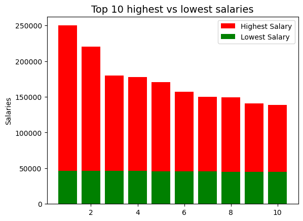

```python
y1 = df['Salary'].sort_values(ascending = False).head(10)
y2 = df['Salary'].sort_values(ascending = False).tail(10)
x = [1,2,3,4,5,6,7,8,9,10]


plt.bar(x, y1, color = 'red', label = "Highest Salary")
plt.bar(x, y2, color = 'green', label = "Lowest Salary")

plt.title('Top 10 highest vs lowest salaries', fontsize = 14)
plt.ylabel("Salaries")
plt.legend()
plt.show()
```

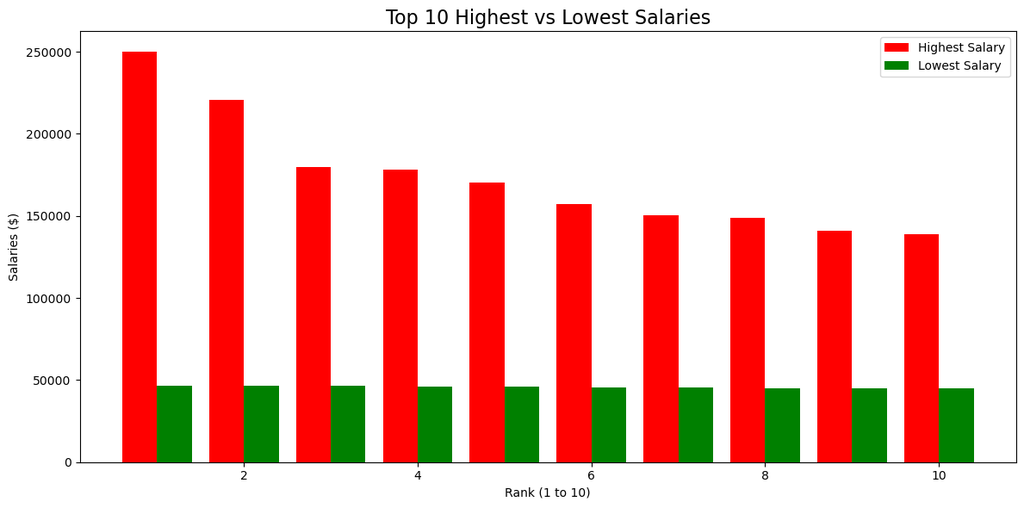

```python
import numpy as np
import matplotlib.pyplot as plt

# Assuming y1 and y2 are your salary lists and x is 1 to 10
y1 = df['Salary'].sort_values(ascending = False).head(10)
y2 = df['Salary'].sort_values(ascending = False).tail(10)
x = np.arange(1, 11) # Use numpy for easier array manipulation
width = 0.4 # The width of the bars

plt.figure(figsize=(12, 6))

# Plotting Highest Salary bars
plt.bar(x - width/2, y1, width, color='red', label='Highest Salary')

# Plotting Lowest Salary bars, shifted to the right
plt.bar(x + width/2, y2, width, color='green', label='Lowest Salary')

plt.title('Top 10 Highest vs Lowest Salaries', fontsize=16)

plt.xlabel("Rank (1 to 10)")
plt.ylabel("Salaries ($)")
plt.legend()
plt.tight_layout()
plt.show()
```

# Minimal Variation at the Extremes:

The top 10 highest salaries show some variation, but they are all in a high range. Similarly, the lowest salaries are grouped closely together, indicating a relatively flat floor for salary.

# Uneven Distribution:

The distribution of salaries is not uniform or symmetrical. It appears to be skewed, with a very large gap between the lowest and highest pay scales.

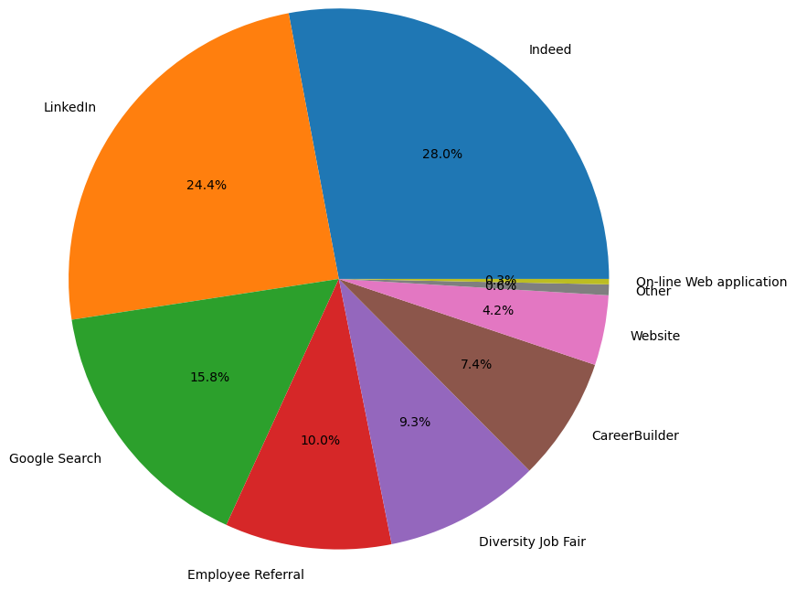

```python
plt.pie(df['RecruitmentSource'].value_counts(),autopct = '%.1f%%', radius = 2, labels = df['RecruitmentSource'].value_counts().index)
plt.show()
```

# Insights from the Pie Chart

The pie chart is best for understanding the proportional share of each recruitment source to the total number of hires.

The Big Three's Share: The three largest slices belong to Indeed (27.97%), LinkedIn (24.43%), and Google Search (15.75%).

Combined Dominance: When combined, these three top sources account for approximately 68% of all hires. This confirms that the company is heavily reliant on these platforms.

Minor Contributions: The smaller slices represent sources with very low recruitment rates. The pie chart makes it visually clear that most of the company's recruitment effort is yielding very little return.

```python
l = df['RecruitmentSource'].value_counts()
l
```

```
RecruitmentSource
Indeed                     87
LinkedIn                   76
Google Search              49
Employee Referral          31
Diversity Job Fair         29
CareerBuilder              23
Website                    13
Other                       2
On-line Web application     1
Name: count, dtype: int64
```

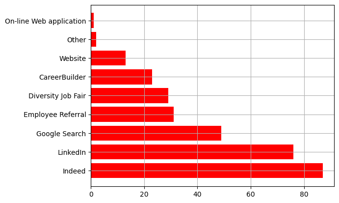

```python
plt.barh(l.index, l, color = 'r')
plt.grid()
```

# Insights:

The data clearly shows that the company's recruitment is highly concentrated and not evenly distributed across all sources. A small number of online platforms are responsible for the vast majority of hires, while many other sources have minimal or negligible contributions.

## Dominance of Top Sources:

The chart immediately highlights the top three recruitment sources by count: Indeed (87 hires), LinkedIn (76 hires), and Google Search (49 hires). Together, these three platforms account for a significant lead over all other sources.

## Effectiveness Comparison:

It's easy to see that an "Employee Referral" (31 hires) is more effective than a "Diversity Job Fair" (29 hires), and much more effective than a "Website" application (13 hires).

```python
df['PerformanceScore'].value_counts()
```

```
PerformanceScore
Fully Meets          243
Exceeds               37
Needs Improvement     18
PIP                   13
Name: count, dtype: int64
```

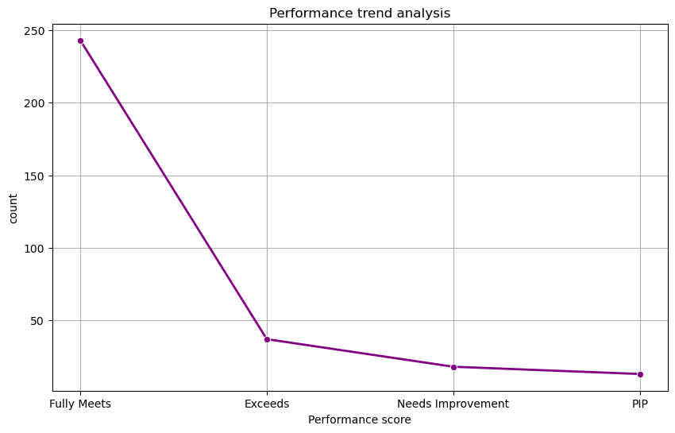

```python
plt.figure(figsize = (10,6))
sns.lineplot(data = df['PerformanceScore'].value_counts(), marker = 'o', color = 'purple', linewidth = 2)
plt.title('Performance trend analysis')
plt.xlabel('Performance score')
plt.grid()
```

# Insights:

The plot shows a steeply decreasing trend in performance scores. The highest number of individuals are in the "Fully Meets" category, with a sharp drop-off to the other categories. This indicates that most of the population is performing well, with a small number of underperforming individuals.

```python
df['EmpSatisfaction'].unique()
```

```
array([5, 3, 4, 2, 1], dtype=int64)
```

```python
x = df['EmpSatisfaction'].value_counts()
x
```

```
EmpSatisfaction
3    108
5     98
4     94
2      9
1      2
Name: count, dtype: int64
```

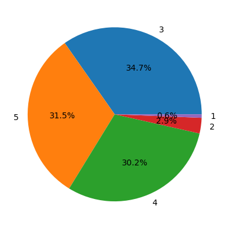

```python
plt.pie(x, autopct = '%.1f%%', labels = x.index)
plt.show()
```

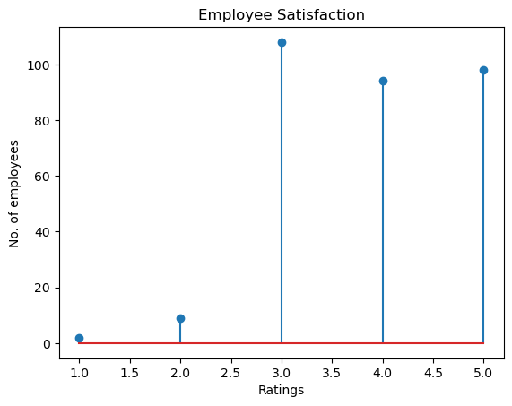

```python
plt.stem(x.index, x)
plt.ylabel('No. of employees')
plt.xlabel('Ratings')
plt.title("Employee Satisfaction")
plt.show()
```

# Insights:

## Highly Satisfied and Moderately Satisfied are Dominant:

The most common ratings are 3 (moderately satisfied) with over 100 employees, and 5 (very satisfied) with almost 100 employees. This indicates a large portion of the workforce is either satisfied or very satisfied.

## Low Dissatisfaction:

The lowest ratings, 1 (very dissatisfied) and 2 (dissatisfied), have very few employees. This is a positive finding, as it suggests that dissatisfaction is not a widespread issue.

# Multi-variate Analysis

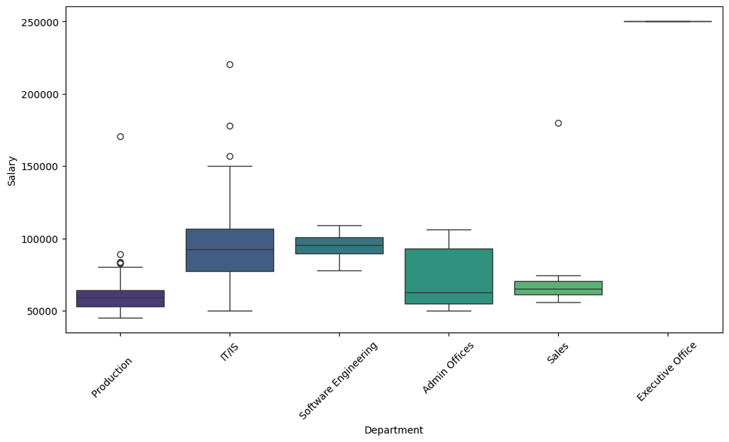

```python
plt.figure(figsize = (12,6))
sns.boxplot(x = 'Department', y = 'Salary', data = df, palette = 'viridis')
plt.xticks(rotation = 45)
plt.show()
```

# Insights

The Executive Office has a salary range that is significantly higher than all other departments, with both its lowest and highest salaries surpassing the highest salaries of the other departments.

The IT/IS and Sales departments have noticeable high-earning outliers, showing a few individuals are paid significantly more than their colleagues.

```python
df['GenderID']
```

```
0      1
1      1
2      0
3      0
4      0
      ..
306    1
307    0
308    0
309    0
310    0
Name: GenderID, Length: 311, dtype: int64
```

```python
df['MaritalDesc']
```

```
0        Single
1       Married
2       Married
3       Married
4      Divorced
         ...
306      Single
307      Single
308      Single
309      Single
310     Widowed
Name: MaritalDesc, Length: 311, dtype: object
```

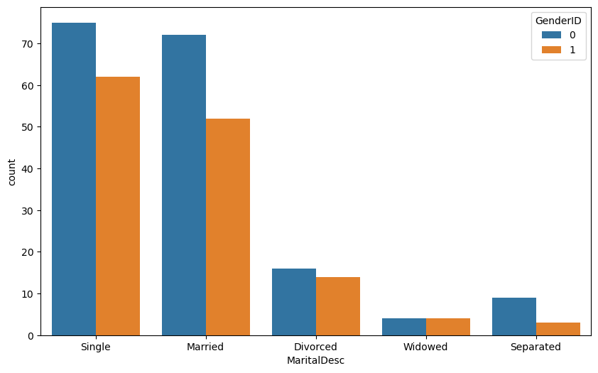

```python
plt.figure(figsize = (10,6))
sns.countplot(x = 'MaritalDesc',hue = 'GenderID', data = df)
```

```python
# What is the average engagement score for employees in each department
```

```python
df.EngagementSurvey.unique()
```

```
array([4.6 , 4.96, 3.02, 4.84, 5.  , 3.04, 4.46, 4.2 , 4.28, 4.4 , 4.5 ,
       2.  , 4.8 , 3.5 , 3.39, 3.35, 3.19, 3.14, 4.51, 3.25, 3.84, 4.43,
       3.3 , 3.8 , 3.  , 4.3 , 3.58, 4.7 , 4.1 , 4.13, 3.7 , 4.73, 4.12,
       4.62, 3.1 , 3.96, 3.79, 1.93, 1.12, 3.01, 2.3 , 3.88, 3.4 , 4.11,
       4.77, 4.52, 2.9 , 2.1 , 4.  , 3.13, 1.56, 1.2 , 4.76, 3.66, 3.73,
       4.24, 3.97, 3.9 , 4.61, 4.63, 4.64, 4.17, 3.6 , 3.03, 4.48, 3.24,
       3.72, 2.34, 3.99, 3.75, 3.07, 4.83, 3.49, 3.38, 3.65, 4.78, 4.9 ,
       4.88, 4.53, 3.18, 4.65, 3.08, 3.93, 4.18, 4.37, 2.39, 3.81, 4.29,
       2.33, 4.25, 3.89, 3.54, 2.4 , 3.45, 4.16, 3.17, 4.15, 3.98, 4.36,
       3.69, 4.94, 2.6 , 3.51, 3.31, 4.81, 3.32, 4.68, 3.27, 1.81, 4.21,
       2.44, 2.81, 4.33, 3.21, 3.11, 2.5 , 3.42, 4.07, 3.2 ])
```

```python
df.groupby('Department')['EngagementSurvey'].mean().sort_values(ascending = False)
```

```
Department
Executive Office        4.830000
Admin Offices           4.393333
IT/IS                   4.154000
Production              4.129569
Software Engineering    4.061818
Sales                   3.818710
Name: EngagementSurvey, dtype: float64
```

# Insights:

Executive Office has highest average engagement survey of about 4.83 followed by Admin Office(4.39) and IT/CS(4.15)

## How many employees have been terminated for each position.

```python
df.columns
```

```
Index(['Employee_Name', 'EmpID', 'MarriedID', 'MaritalStatusID', 'GenderID',
       'EmpStatusID', 'DeptID', 'PerfScoreID', 'FromDiversityJobFairID',
       'Salary', 'Termd', 'PositionID', 'Position', 'State', 'Zip', 'DOB',
       'Sex', 'MaritalDesc', 'CitizenDesc', 'HispanicLatino', 'RaceDesc',
       'DateofHire', 'DateofTermination', 'TermReason', 'EmploymentStatus',
       'Department', 'ManagerName', 'ManagerID', 'RecruitmentSource',
       'PerformanceScore', 'EngagementSurvey', 'EmpSatisfaction',
       'SpecialProjectsCount', 'LastPerformanceReview_Date', 'DaysLateLast30',
       'Absences'],
      dtype='object')
```

```python
df.Termd.value_counts()
```

```
Termd
0    207
1    104
Name: count, dtype: int64
```

```python
df[df['Termd']==1].groupby('Position')['Employee_Name'].count()
```

```
Position
Administrative Assistant     2
Area Sales Manager           4
Data Analyst                 1
Data Analyst                 1
Database Administrator       3
Enterprise Architect         1
IT Manager - DB              1
Network Engineer             1
Principal Data Architect     1
Production Manager           5
Production Technician I     52
Production Technician II    26
Sales Manager                1
Software Engineer            4
Sr. DBA                      1
Name: Employee_Name, dtype: int64
```

## How many employees have been terminated for each reason.

```python
df['TermReason'].unique()
```

```
array(['N/A-StillEmployed', 'career change', 'hours', 'return to school',
       'Another position', 'unhappy', 'attendance', 'performance',
       'Learned that he is a gangster', 'retiring',
       'relocation out of area', 'more money', 'military',
       'no-call, no-show', 'Fatal attraction',
       'maternity leave - did not return', 'medical issues',
       'gross misconduct'], dtype=object)
```

```python
df[df['Termd'] == 1].groupby('TermReason')["Employee_Name"].count()
```

```
TermReason
Another position                    20
Fatal attraction                     1
Learned that he is a gangster        1
attendance                           7
career change                        9
gross misconduct                     1
hours                                8
maternity leave - did not return     3
medical issues                       3
military                             4
more money                          11
no-call, no-show                     4
performance                          4
relocation out of area               5
retiring                             4
return to school                     5
unhappy                             14
Name: Employee_Name, dtype: int64
```

## What is the median salary of male and female employees

```python
df.groupby('Sex')['Salary'].median()
```

```
Sex
F     62066.5
M     63353.0
Name: Salary, dtype: float64
```

## What is the total absences and and average engagement survey score for each department

```python
df.columns
```

```
Index(['Employee_Name', 'EmpID', 'MarriedID', 'MaritalStatusID', 'GenderID',
       'EmpStatusID', 'DeptID', 'PerfScoreID', 'FromDiversityJobFairID',
       'Salary', 'Termd', 'PositionID', 'Position', 'State', 'Zip', 'DOB',
       'Sex', 'MaritalDesc', 'CitizenDesc', 'HispanicLatino', 'RaceDesc',
       'DateofHire', 'DateofTermination', 'TermReason', 'EmploymentStatus',
       'Department', 'ManagerName', 'ManagerID', 'RecruitmentSource',
       'PerformanceScore', 'EngagementSurvey', 'EmpSatisfaction',
       'SpecialProjectsCount', 'LastPerformanceReview_Date', 'DaysLateLast30',
       'Absences'],
      dtype='object')
```

```python
df['Absences'].sum()
```

```
3184
```

```python
df['EngagementSurvey'].mean()
```

```
4.11
```

```python
df.groupby('Department')['Absences'].sum()
```

```
Department
Admin Offices             78
Executive Office          10
IT/IS                    522
Production              2120
Sales                    358
Software Engineering      96
Name: Absences, dtype: int64
```

```python
df.groupby('Department')['EngagementSurvey'].mean()
```

```
Department
Admin Offices           4.393333
Executive Office        4.830000
IT/IS                   4.154000
Production              4.129569
Sales                   3.818710
Software Engineering    4.061818
Name: EngagementSurvey, dtype: float64
```

```python
df.groupby('Department').agg({'Absences' : 'sum', 'EngagementSurvey' : 'mean'})
```

| Department | Absences | EngagementSurvey |
| --- | --- | --- |
| Admin Offices | 78 | 4.393333 |
| Executive Office | 10 | 4.830000 |
| IT/IS | 522 | 4.154000 |
| Production | 2120 | 4.129569 |
| Sales | 358 | 3.818710 |
| Software Engineering | 96 | 4.061818 |

## What is the total number of special projects and average absences for employees in each gender.

```python
df.groupby('Sex').agg({'SpecialProjectsCount' : 'sum', 'Absences' : 'mean'})
```

| Sex | SpecialProjectsCount | Absences |
| --- | --- | --- |
| F | 183 | 10.261364 |
| M | 196 | 10.207407 |

## What is maximum salary and minimum days late in the last 30 days for employees in each position

```python
df.groupby('Position').agg({'Salary': 'max', 'DaysLateLast30': 'min'})
```

| Position | Salary | DaysLateLast30 |
| --- | --- | --- |
| Accountant I | 64520 | 0 |
| Administrative Assistant | 55000 | 0 |
| Area Sales Manager | 74326 | 0 |
| BI Developer | 99020 | 0 |
| BI Director | 110929 | 0 |
| CIO | 220450 | 0 |
| Data Analyst | 93554 | 0 |
| Data Analyst | 88527 | 0 |
| Data Architect | 150290 | 0 |
| Database Administrator | 114800 | 0 |
| Director of Operations | 170500 | 0 |
| Director of Sales | 180000 | 0 |
| Enterprise Architect | 103613 | 0 |
| IT Director | 178000 | 0 |
| IT Manager - DB | 148999 | 0 |
| IT Manager - Infra | 157000 | 4 |
| IT Manager - Support | 138888 | 0 |
| IT Support | 74679 | 0 |
| Network Engineer | 76029 | 0 |
| President & CEO | 250000 | 0 |
| Principal Data Architect | 120000 | 0 |
| Production Manager | 88976 | 0 |
| Production Technician I | 64991 | 0 |
| Production Technician II | 74813 | 0 |
| Sales Manager | 72992 | 0 |
| Senior BI Developer | 87921 | 0 |
| Shared Services Manager | 93046 | 0 |
| Software Engineer | 108987 | 0 |
| Software Engineering Manager | 77692 | 0 |
| Sr. Accountant | 106367 | 0 |
| Sr. DBA | 104437 | 0 |
| Sr. Network Engineer | 107226 | 0 |

```python
df.columns
```

```
Index(['Employee_Name', 'EmpID', 'MarriedID', 'MaritalStatusID', 'GenderID',
       'EmpStatusID', 'DeptID', 'PerfScoreID', 'FromDiversityJobFairID',
       'Salary', 'Termd', 'PositionID', 'Position', 'State', 'Zip', 'DOB',
       'Sex', 'MaritalDesc', 'CitizenDesc', 'HispanicLatino', 'RaceDesc',
       'DateofHire', 'DateofTermination', 'TermReason', 'EmploymentStatus',
       'Department', 'ManagerName', 'ManagerID', 'RecruitmentSource',
       'PerformanceScore', 'EngagementSurvey', 'EmpSatisfaction',
       'SpecialProjectsCount', 'LastPerformanceReview_Date', 'DaysLateLast30',
       'Absences'],
      dtype='object')
```

## What is earliest and latest date of hire for employees in each managers team

```python
df['DateofHire']
```

```
0       7/5/2011
1      3/30/2015
2       7/5/2011
3       1/7/2008
4      7/11/2011
         ...
306     7/7/2014
307     9/2/2008
308    4/10/2010
309    3/30/2015
310    9/29/2014
Name: DateofHire, Length: 311, dtype: object
```

```python
df['DateofHire'] = pd.to_datetime(df['DateofHire'])
df.DateofHire
```

```
0     2011-07-05
1     2015-03-30
2     2011-07-05
3     2008-01-07
4     2011-07-11
         ...
306   2014-07-07
307   2008-09-02
308   2010-04-10
309   2015-03-30
310   2014-09-29
Name: DateofHire, Length: 311, dtype: datetime64[ns]
```

```python
df['DateofHire'].sort_values()
```

```
282   2006-01-09
280   2007-06-25
222   2007-11-05
3     2008-01-07
307   2008-09-02
         ...
298   2017-02-15
70    2017-02-15
275   2017-04-20
120   2017-04-20
64    2018-07-09
Name: DateofHire, Length: 311, dtype: datetime64[ns]
```

```python
df.groupby('ManagerName').agg(Latest_DOH = ('DateofHire', 'max'), Earliest_DOH = ('DateofHire', 'min'))
```

| ManagerName | Latest_DOH | Earliest_DOH |
| --- | --- | --- |
| Alex Sweetwater | 2014-11-10 | 2011-05-02 |
| Amy Dunn | 2015-05-11 | 2011-01-10 |
| Board of Directors | 2012-07-02 | 2009-01-05 |
| Brandon R. LeBlanc | 2015-05-01 | 2008-10-27 |
| Brannon Miller | 2018-07-09 | 2008-09-02 |
| Brian Champaigne | 2017-04-20 | 2016-10-02 |
| David Stanley | 2015-03-30 | 2007-11-05 |
| Debra Houlihan | 2014-05-18 | 2011-11-07 |
| Elijiah Gray | 2016-06-06 | 2008-01-07 |
| Eric Dougall | 2012-09-05 | 2010-05-01 |
| Janet King | 2016-01-28 | 2009-01-05 |
| Jennifer Zamora | 2016-09-06 | 2011-04-15 |
| John Smith | 2015-01-05 | 2010-09-27 |
| Kelley Spirea | 2016-07-21 | 2010-08-30 |
| Ketsia Liebig | 2015-03-30 | 2010-04-26 |
| Kissy Sullivan | 2014-07-07 | 2011-01-10 |
| Lynn Daneault | 2016-07-06 | 2006-01-09 |
| Michael Albert | 2016-07-06 | 2009-01-05 |
| Peter Monroe | 2016-06-30 | 2014-09-30 |
| Simon Roup | 2016-06-30 | 2014-02-17 |
| Webster Butler | 2016-05-11 | 2007-06-25 |

## How many terminated employees were there in each department and what is average employee satisfaction level in team

```python
df.groupby('Department').agg(
    Total_Terminated_Employees=('Termd', 'sum'),
    Average_Employee_Satisfaction=('EmpSatisfaction', 'mean')
)
```

| Department | Total_Terminated_Employees | Average_Employee_Satisfaction |
| --- | --- | --- |
| Admin Offices | 2 | 3.555556 |
| Executive Office | 0 | 3.000000 |
| IT/IS | 10 | 3.960000 |
| Production | 83 | 3.861244 |
| Sales | 5 | 4.032258 |
| Software Engineering | 4 | 4.090909 |

```python
df.groupby('Department').agg({'Termd' : 'sum',  'EmpSatisfaction': 'mean'})
```

| Department | Termd | EmpSatisfaction |
| --- | --- | --- |
| Admin Offices | 2 | 3.555556 |
| Executive Office | 0 | 3.000000 |
| IT/IS | 10 | 3.960000 |
| Production | 83 | 3.861244 |
| Sales | 5 | 4.032258 |
| Software Engineering | 4 | 4.090909 |